# Random Forests with Python

# Introduction

Properties in various states of disrepair, collectively referred to as blight, are a costly and wide-spread problem in Detroit, affecting over 20% of its properties. Detroit’s declining population, a consequence of auto-industry job loss and increased suburbinization, fell from a peak of 1,800,000 in 1950 to around 700,000 residents in 2017, leading to unprecidented rates of property abandonment. This trend received a boost in 2005 as sub-prime mortgages accounted for 68% of all mortgages in Detroit. Since then, Detroit has encountered over 65,000 mortgage foreclosures, totaling over 1/6 of the total number of parcels in the city. Fifty-six percent of those foreclosures are now blighted or abandoned.

In 2005, the City of Detroit began issuing blight violation citations to encourage homeowners to keep their properties in good conduction and to help finance blight remediation. These so-called blight tickets, ranging from $20 for trash collection day offenses to $10,000 for excessive waste dumping, may be contested in a hearing. If the violation is fixed before the hearing, the person would be deemed ‘not responsible’ for the ticket.

Every year, the city of Detroit issues millions of dollars in fines to residents and every year, many of these fines remain unpaid. In fact, the compliance rate for blight tickets in which the person is deemed responsible is approximately 7%. Nearly 93% of fines never get paid,leaving over $70,000,000 in unpaid blight tickets since 2005.

## Problem Definition

Enforcing unpaid blight fines is a costly and tedious process, as such the city seeks to understand the factors associated with low blight ticket compliance.

## Project Overview

The two fold objective of this project is to:  
1. analyze and interpret the factors associated with low blight ticket compliance, and  
2. build a random-forests based model to predict blight ticket compliance

The project will unfold in a six-part series including:  
* Initial Data Analysis  
* Exploratory Data Analysis * Feature Engineering * Introduction to Random Forests  
* Random Forests Model Building  
* Model Evaluation and Conclusion

The project, source code and data are available at https://github.com/DataScienceSalon/Random-Forests-with-Python

# Initial Data Analysis

The primary concern of the initial data analysis is data quality and engages questions such as:  
1. How should missing and faulty data be treated?  
2. Do data properties agree with expectations?  
3. What initial data transformations would be appropriate?  
4. What are the distribution and frequency characteristics of categorical variables?  
5. What inconsistencies exist and what should be done about them?  
6. What outliers exist and what are the implications for further statistical analyses?

This article will examine the Detroit Blight Ticket Data in some detail, examine the data and their properties, illuminate any inconsistencies and prescribe treatments and corrective actions which will be implemented in the following data preparation phase.

## Blight Ticket Data

The data for this project was made available courtesy of the publicly accessible Detroit Open Data Portal. Available blight ticket data has been split into a training set containing observations from 2005-2011 and a test set including blight tickets written between 2012 and 2016. Each row in these two files corresponds to a single blight ticket, and includes information about when, why, and to whom each ticket was issued. The target variable is compliance, which is True if the ticket was paid early, on time, or within one month of the hearing date, False if the ticket was paid after the hearing date or not at all, and Null if the violator was found not responsible. Compliance, as well as a handful of other variables that will not be available at test-time, are only included in train.csv. In addition, all tickets where the violators were determined to be “not responsible” are not considered during evaluation. They are included in the training set as an additional source of data for visualization, and to enable unsupervised and semi-supervised approaches. Here are the variables and their definitions.

train.csv & test.csv

- ticket_id - unique identifier for tickets
- agency_name - Agency that issued the ticket
- inspector_name - Name of inspector that issued the ticket
- violator_name - Name of the person/organization that the ticket was issued to
- violation_street_number, violation_street_name, violation_zip_code - Address where the violation occurred
- mailing_address_str_number, mailing_address_str_name, city, state, zip_code, non_us_str_code, country - Mailing address of the violator
- ticket_issued_date - Date and time the ticket was issued
- hearing_date - Date and time the violator’s hearing was scheduled
- violation_code, violation_description - Type of violation
- disposition - Judgment and judgement type
- fine_amount - Violation fine amount, excluding fees
- admin_fee - $20 fee assigned to responsible judgments
- state_fee - $10 fee assigned to responsible judgments
- late_fee - 10% fee assigned to responsible judgments
- discount_amount - discount applied, if any
- clean_up_cost - DPW clean-up or graffiti removal cost
- judgment_amount - Sum of all fines and fees
- grafitti_status - Flag for graffiti violations

train.csv only

- payment_amount - Amount paid, if any
- payment_date - Date payment was made, if it was received
- payment_status - Current payment status as of Feb 1 2017
- balance_due - Fines and fees still owed
- collection_status - Flag for payments in collections
- compliance [target variable for prediction]
- Null = Not responsible  
  0 = Responsible, non-compliant  
  1 = Responsible, compliant
- compliance_detail - More information on why each ticket was marked compliant or non-compliant

The blight dataframe summarized contains 250,306 blight ticket observations and 37 variables.

Two additional files, addresses.csv and latlons.csv have been provided for geolocation purposes. The former contains the violation addresses mapped to ticket_ids and the latter maps the addresses to latitude and longitude coordinates.

Not every variable will be relevant to, or useful for, analysis and modeling. Let’s trim the dataset down to the relevant observations and variables.

## Data Selection

Here, we will identify the relevant observations and variables and eliminate the superfluous, redundant, and tangential data. We are only interested in tickets in which the violator was deemed ‘responsible’, those tickets with a ‘not responsible’ designation will be removed. Variables containing payment and balance information are only included in the training set and can therefore be discarded. Redundant variables such as those containing fees, costs and discounts can also be eliminated from further analysis.

The trimmed dataframe described in Figure 1 now contains 159,880 observations and the following 16 variables. We can now proceed with the univariate data analysis.

```
<class 'pandas.core.frame.DataFrame'>
Int64Index: 159880 entries, 0 to 250296
Data columns (total 16 columns):
agency_name                159880 non-null object
inspector_name             159880 non-null object
violator_name              159854 non-null object
violation_street_number    159880 non-null float64
violation_street_name      159880 non-null object
city                       159880 non-null object
state                      159796 non-null object
zip_code                   159879 non-null object
country                    159880 non-null object
lat                        159878 non-null float64
lon                        159878 non-null float64
ticket_issued_date         159880 non-null object
hearing_date               159653 non-null object
violation_code             159880 non-null object
judgment_amount            159880 non-null float64
compliance                 159880 non-null float64
dtypes: float64(5), object(11)
memory usage: 20.7+ MB
None
```

Figure 1: Selected Blight Ticket Data Variables

## Univariate Analysis

Again, the univariate data analysis is primarily concerned with characterizing the quality of the data. The following descriptive statistics and frequency analyses will inform our downstream data processing, feature selection, feature engineering and modeling decisions.

Let’s start with the target variable, Compliance. Por qué no?

### Compliance

The compliance variable contains either zero or one for all observations as expected. As graphically depicted in Figure 2, the vast majority of blight tickets (92.7%) were ‘Non-Compliant’ and there are no missing values.

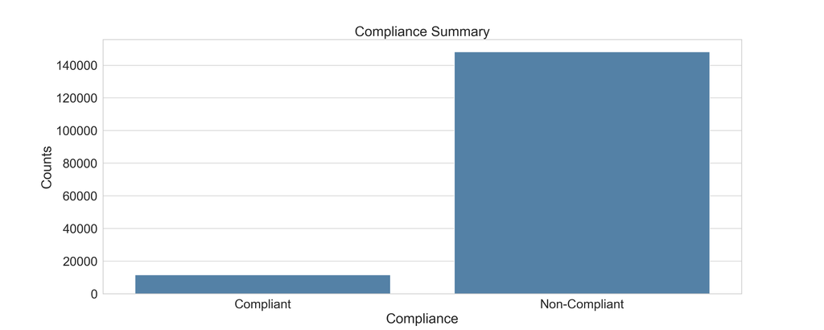

Figure 2: Compliance Summary

Table 1: Compliance Distribution

| Compliance | Counts | Percent |
| --- | --- | --- |
| Compliant | 11597 | 7.3 |
| Non-Compliant | 148283 | 92.7 |

Though no data quality issues present at this stage, a 7.3% compliance rate is rather abysmal indeed.

### Agency

Figure 3 shows 159,880 blight tickets originating from one of the five enforcement agencies and there are no missing values for this variable.

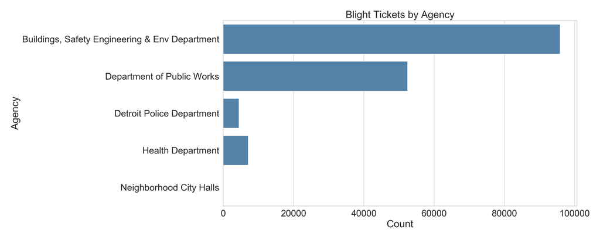

Figure 3: Blight Tickets by Agency

Table 2: Blight Tickets by Agency

| Agency | Count | Percent |
| --- | --- | --- |
| Buildings, Safety Engineering & Env Department | 95863 | 60.0 |
| Department of Public Works | 52445 | 32.8 |
| Detroit Police Department | 4464 | 2.8 |
| Health Department | 7107 | 4.4 |
| Neighborhood City Halls | 1 | 0.0 |

As shown in Table 2, Neighborhood City Halls are responsible for just a single blight ticket. To ensure an adequate number of observations per categorical level, we’ll combine the Neighhborhood City Halls and Detroit Police Department levels into a single categorical level.

### Inpector

Figure 4 shows 159,880 blight tickets originating from one of the 159 inspectors and there are no missing values for this variable.

Table 3: Blight Tickets by Inspector Summary

|  | observations | count | missing | pct_missing | unique | top | freq |
| --- | --- | --- | --- | --- | --- | --- | --- |
| inspector_name | 159880 | 159880 | 0 | 0 | 159 | Morris, John | 11604 |

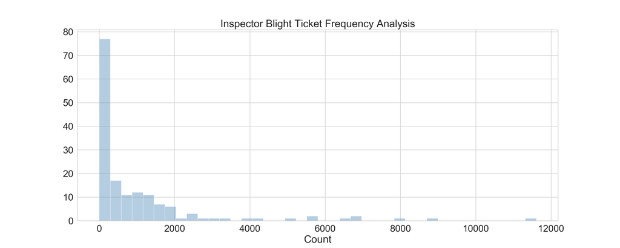

Figure 4: Inspector Blight Ticket Frequency Histogram

Table 4: Blight Tickets by Inspector Frequency Analysis

|  | count | mean | std | min | 25% | 50% | 75% | max |
| --- | --- | --- | --- | --- | --- | --- | --- | --- |
| Count | 159 | 1005.5 | 1785.7 | 1 | 21 | 378 | 1287 | 11604 |

As indicated in Figure 4, the distribution of blight ticket counts among the inspectors is significantly right-skewed. The median number of tickets per inspector is 378; whereas, the mean is approximately 1,006 tickets, a differencing owing to outlier inspectors with upwards of 11,604 blight tickets written as shown in Table 5. We’ll need to determine, during the exploratory phase, the degree to which these outliers influence the regression and decide upon an appropriate treatment.

Table 5: Top 10 Inspectors by Blight Tickets Written

|  | Count |
| --- | --- |
| Morris, John | 11604 |
| Samaan, Neil J | 8720 |
| O’Neal, Claude | 8075 |
| Steele, Jonathan | 6962 |
| Devaney, John | 6837 |
| Hayes, Billy J | 6385 |
| Sloane, Bennie J | 5624 |
| Sims, Martinzie | 5526 |
| Zizi, Josue | 5060 |
| Doetsch, James | 4337 |

No data quality issues appear extant. That said, we may want to consider adding two new variables to capture the quantity and quality of tickets issued by an inspector in terms of the overall number of tickets written and the percentage of those tickets which were compliant. This will allow us to categorize inspectors based upon compliance percentage, thereby reducing the number categorical levels to something more tractable. Let’s put a pin in it for now and revisit this during the exploratory phase.

### Violation Code

Table 6 confirms that each of the 159,880 observations was written against one of 189 violation codes. There are no missing values.

Table 6: Blight Tickets by Violation Code Summary

|  | observations | count | missing | pct_missing | unique | top | freq |
| --- | --- | --- | --- | --- | --- | --- | --- |
| violation_code | 159880 | 159880 | 0 | 0 | 189 | 9-1-36(a) | 64414 |

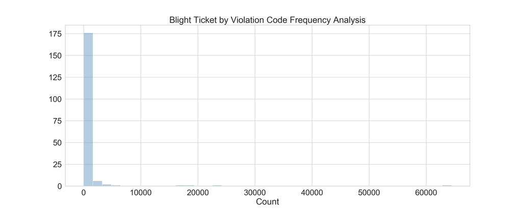

Figure 5: Blight Ticket by Violation Code Frequency Histogram

Table 7: Blight Ticket by Violation Code Frequency Analysis

|  | count | mean | std | min | 25% | 50% | 75% | max |
| --- | --- | --- | --- | --- | --- | --- | --- | --- |
| Count | 189 | 845.9 | 5308.6 | 1 | 2 | 8 | 46 | 64414 |

Again, we have another significantly right-skewed frequency distribution. Whereas half of the violation codes have 8 or fewer blight tickets, there are others with upwards of 64,414 tickets as shown in Table 8.

Table 8: Top 10 Violations by Blight Tickets Written

|  | Count |
| --- | --- |
| 9-1-36(a) | 64414 |
| 9-1-81(a) | 23145 |
| 22-2-88 | 19073 |
| 9-1-104 | 16927 |
| 22-2-88(b) | 4879 |
| 22-2-45 | 4200 |
| 9-1-105 | 3619 |
| 9-1-110(a) | 3147 |
| 9-1-43(a) - (Dwellin | 3043 |
| 9-1-103(C) | 2641 |

There are no obvious data quality issues with this variable, and as with inspector, we may also consider the quantity of past tickets written against a violation code as well as the percentage of tickets that were compliant. As with inspector, we can create a new violation code compliance variable based upon compliance percentage thereby reducing the number of categorical levels associated with violations.

Again, we’ll take a note and re-address this at feature engineering time.

### Violator

As indicated below, there are 26 missing values for the violator_name variable. Rather than removing these observations, we can impute the missing violation names with the violation street address.

Table 9: Blight Tickets by Violator Summary

|  | observations | count | missing | pct_missing | unique | top | freq |
| --- | --- | --- | --- | --- | --- | --- | --- |
| violator_name | 159880 | 159880 | 26 | 0 | 84657 | INVESTMENT, ACORN | 624 |

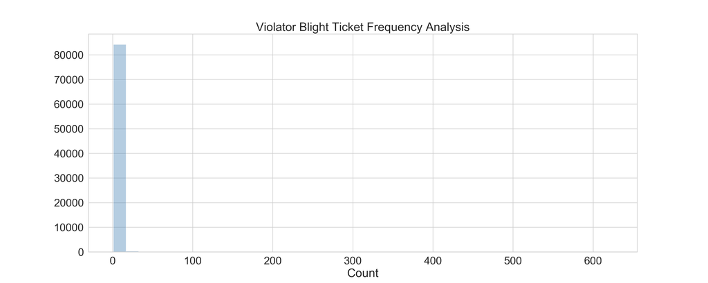

Figure 6: Blight Ticket by Violator Frequency Histogram

Table 10: Blight Ticket by Violator Frequency Analysis

|  | count | mean | std | min | 25% | 50% | 75% | max |
| --- | --- | --- | --- | --- | --- | --- | --- | --- |
| Count | 84656 | 1.9 | 3.9 | 1 | 1 | 1 | 2 | 624 |

As depicted in Figure 6 and in Table 10, most violators have just a single violation; however, there are repeat offenders with upwards of 624 violations. The top 10 offenders are listed in Table 11.

Table 11: Top 10 Violations by Blight Tickets Written

|  | Count |
| --- | --- |
| INVESTMENT, ACORN | 624 |
| INVESTMENT CO., ACORN | 343 |
| BANK, WELLS FARGO | 253 |
| MILLER, JOHN | 177 |
| STEHLIK, JERRY | 158 |
| NEW YORK, BANK OF | 142 |
| KRAMER, KEITH | 119 |
| SNOW, GEORGE | 108 |
| APARTMENTS, CARLTON | 102 |
| NATIONAL TRUST CO., DEUTSCHE BANK | 102 |

Again, we see no obvious data quality issues with this variable; as such, we may consider differentiating repeat offenders by assigning violators to one of several groups, based upon the number of offenses. A compliance rate categorical variable will allow us to categorize violators in terms of past compliance.

### Violation Street

Each of the 159,880 observations was written against a parcel on one of 1,716 streets in Detroit. There are no missing values for this variable.

Table 12: Blight Tickets by Street Summary

|  | observations | count | missing | pct_missing | unique | top | freq |
| --- | --- | --- | --- | --- | --- | --- | --- |
| violation_street_name | 159880 | 159880 | 0 | 0 | 1716 | SEVEN MILE | 2373 |

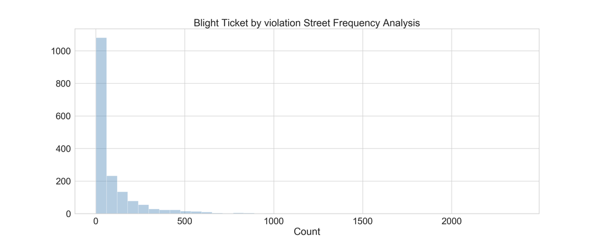

Figure 7: Blight Ticket by Street Frequency Histogram

Table 13: Blight Ticket by Street Frequency Analysis

|  | count | mean | std | min | 25% | 50% | 75% | max |
| --- | --- | --- | --- | --- | --- | --- | --- | --- |
| Count | 1716 | 93.2 | 166.2 | 1 | 6 | 29 | 111 | 2373 |

As depicted in Figure 7 and in Table 13, the median number of tickets per street is 29; however, the mean is 93 tickets per street. This is owing to outlier streets which have upwards of 2,373 blight tickets written. We’ll need to examine the effects of the outliers during exploration.

The 10 most frequently tickets streets are listed in Table 14.

Table 14: Top 10 Streets by Blight Tickets Written

|  | Count |
| --- | --- |
| SEVEN MILE | 2373 |
| MCNICHOLS | 2144 |
| LIVERNOIS | 1607 |
| GRAND RIVER | 1185 |
| EVERGREEN | 1067 |
| WARREN | 998 |
| FENKELL | 997 |
| ASBURY PARK | 900 |
| WYOMING | 872 |
| GRATIOT | 863 |

Once more, we should consider characterizing streets by the number of tickets written and the percentage of those tickets that were compliant.

### City (Mailing)

The city variable corresponds to the mailing address of the violator, distinct from the violation address. There is a city value for each of the 159,880 observations.

Table 15: Blight Tickets by Mailing City Summary

|  | observations | count | missing | pct_missing | unique | top | freq |
| --- | --- | --- | --- | --- | --- | --- | --- |
| city | 159880 | 159880 | 0 | 0 | 4093 | DETROIT | 87426 |

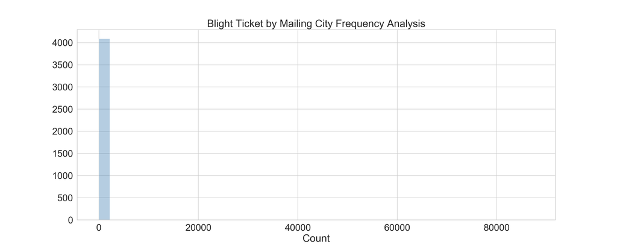

Figure 8: Blight Ticket by Mailing City Frequency Histogram

Table 16: Blight Ticket by Mailing City Frequency Analysis

|  | count | mean | std | min | 25% | 50% | 75% | max |
| --- | --- | --- | --- | --- | --- | --- | --- | --- |
| Count | 4093 | 39.1 | 1379.3 | 1 | 1 | 2 | 4 | 87426 |

Table 17: Top 10 Mailing Cities by Blight Tickets Written

|  | Count |
| --- | --- |
| DETROIT | 87426 |
| SOUTHFIELD | 8790 |
| Detroit | 6374 |
| DEARBORN | 2408 |
| detroit | 2197 |
| FARMINGTON HILLS | 1468 |
| OAK PARK | 1436 |
| WARREN | 1235 |
| W. BLOOMFIELD | 1033 |
| DET | 1010 |

Any analysis based upon city would require some cleaning and normalization of this field as evidenced by the various spellings and representations of the city of Detroit in Table 17.

### State

Table 18 indicates that there are 84 missing values for state. This can be a consequence of having non-US violators or omission. We can adopt the following imputation strategy. If the country variable is US, we’ll assume the state is Michigan. For NON-US violators, we’ll leave the value null as is.

Table 18: Blight Tickets by Mailing State Summary

|  | observations | count | missing | pct_missing | unique | top | freq |
| --- | --- | --- | --- | --- | --- | --- | --- |
| state | 159880 | 159880 | 84 | 0.1 | 60 | MI | 143655 |

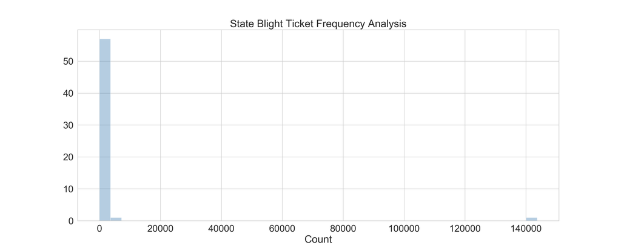

Figure 9: Blight Ticket by Mailing State Frequency Histogram

Table 19: Blight Ticket by Mailing State Frequency Analysis

|  | count | mean | std | min | 25% | 50% | 75% | max |
| --- | --- | --- | --- | --- | --- | --- | --- | --- |
| Count | 59 | 2708.4 | 18675.7 | 1 | 19 | 96 | 288 | 143655 |

|  | Count |
| --- | --- |
| MI | 143655 |
| CA | 3828 |
| TX | 1952 |
| FL | 1680 |
| SC | 1066 |
| IL | 896 |
| OH | 639 |
| NY | 535 |
| MN | 447 |
| GA | 405 |

### Zip Code

The zip code variable pertains to the mailing address of the violator, and not the violation address. The training set, as indicated in Table 21, has 1 missing value for zip_code.

Table 21: Blight Tickets by Zip Code Summary

|  | observations | count | missing | pct_missing | unique | top | freq |
| --- | --- | --- | --- | --- | --- | --- | --- |
| zip_code | 159880 | 159880 | 1 | 0 | 3499 | 48227 | 7316 |

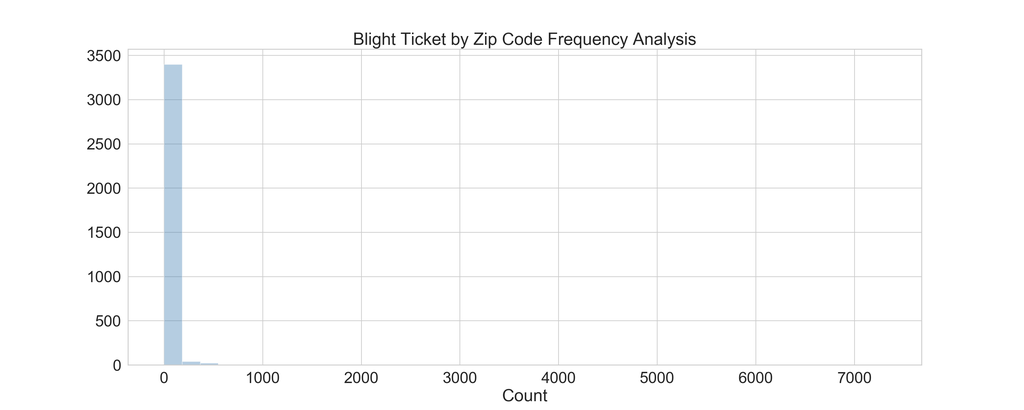

Figure 10: Blight Ticket by Zip Code Frequency Histogram

Table 22: Blight Ticket by Zip Code Frequency Analysis

|  | count | mean | std | min | 25% | 50% | 75% | max |
| --- | --- | --- | --- | --- | --- | --- | --- | --- |
| Count | 3498 | 45.7 | 372.1 | 1 | 1 | 2 | 5 | 7316 |

As depicted in Figure 10 and in Table 22, the median number of tickets per zip code is 2; however, the mean is 46 tickets per zip_code. Another right-skewed distribution with some zip codes having up to 7,316 violations as revealed in Table 23.

Table 23: Top 10 Zip Codes by Blight Tickets Written

|  | Count |
| --- | --- |
| 48227 | 7316 |
| 48221 | 7213 |
| 48235 | 6842 |
| 48228 | 6026 |
| 48219 | 5875 |
| 48238 | 5435 |
| 48224 | 5421 |
| 48205 | 4764 |
| 48204 | 4357 |
| 48234 | 4057 |

Aside from the single missing value, there are no obvious data quality issues with this variable. That said, the zip code variable may be too granular to be useful as a predictor since it would require 3,499 categorical levels. We may consider creating a new variable from the first three numbers of the zip code which pertain to regional areas.

### Country

Blight violators hale from one of 5 countries; however nearly 100% are US based.

Table 24: Blight Tickets by Country

| Country | Count | Percent |
| --- | --- | --- |
| Aust | 2 | 0 |
| Cana | 6 | 0 |
| Egyp | 2 | 0 |
| Germ | 1 | 0 |
| USA | 159869 | 100 |

Given this inbalance, country would not be a useful categorical variable for analysis and prediction.

### Latitude / Longitude

The following rather course summary of latitude and longtitude shows no glaring data quality problems aside from the two missing variables.

Table 25: Summary of Latitude and Longitude Variables

|  | count | mean | std | min | 25% | 50% | 75% | max |
| --- | --- | --- | --- | --- | --- | --- | --- | --- |
| lat | 159878 | 42.39 | 0.04 | 42.15 | 42.36 | 42.39 | 42.42 | 44.79 |
| lon | 159878 | -83.11 | 0.09 | -84.40 | -83.19 | -83.12 | -83.03 | -82.51 |

This data will be useful for a geolocation based visualization of the blight ticket data.

### Dates

Ticket issued dates appear to be in satisfactory condition and there are no missing dates; however we do have tickets dated back to 1988 in the training set. According to the data source, the ticket dates were to start in 2005. We’ll need to examine such outliers during the next phase.

Two additional issues arise upon examination of the hearing dates. First, there are over 200 missing hearing dates and there are 81 observations where the hearing date did not follow the date in which the ticket was issued. A sample of the potential errors are listed in Table 26.

Table 27: Summary of Ticket Issued and Hearing Dates

|  | observations | count | missing | pct_missing | unique | start | end | top | freq |
| --- | --- | --- | --- | --- | --- | --- | --- | --- | --- |
| ticket_issued_date | 159880 | 159880 | 0 | 0.00 | 68097 | 1988-05-06 | 2011-12-30 | 2007-12-21 09:00:00 | 60 |
| hearing_date | 159880 | 159880 | 227 | 0.14 | 5971 | 2005-01-27 | 2016-11-22 | 2005-12-20 09:00:00 | 590 |

Table 26: Sampling of Date Errors

|  | ticket_issued_date | hearing_date |
| --- | --- | --- |
| 178231 | 2008-03-27 13:15:00 | 2008-03-18 10:30:00 |
| 237344 | 2010-04-29 10:30:00 | 2010-04-22 09:00:00 |
| 212521 | 2011-12-16 09:40:00 | 2011-03-10 09:00:00 |
| 183283 | 2010-12-08 09:00:00 | 2010-05-13 09:00:00 |
| 27557 | 2008-03-27 13:00:00 | 2008-03-18 10:30:00 |
| 185980 | 2007-12-30 13:45:00 | 2007-12-13 10:30:00 |
| 144914 | 2006-12-28 13:15:00 | 2006-12-20 10:30:00 |
| 114641 | 2007-12-27 15:00:00 | 2007-12-20 10:30:00 |
| 249028 | 2011-09-30 10:00:00 | 2011-09-22 10:30:00 |
| 197062 | 2010-04-29 10:10:00 | 2010-04-22 09:00:00 |

For both the missing and presumably incorrect hearing dates, new hearing dates may be imputed based upon the mean interval between ticket issued dates and hearing dates, overall or at the violation code level. We should also create a variable to capture the interval between the ticket issued date and the hearing date. A variable that represents the financial costs vis-a-vis the time allotted for payment might be interesting as well.

### Judgment Amount

Alas, we come to the last variable for this univariate exploration. Judgment amounts covered a significant range from $0 upwards to $11,030. An inspection of the data revealed 195 observations with zero judgment amounts. All of these blight tickets were judged ‘compliant by no fine’.

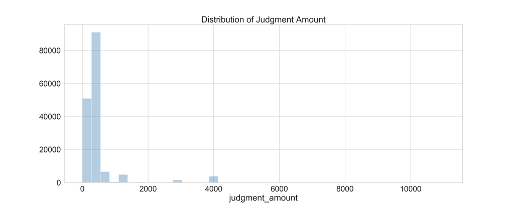

Figure 11: Distribution of Judgment Amounts

Table 28: Distribution of Judgment Amounts

|  | count | mean | std | min | 25% | 50% | 75% | max |
| --- | --- | --- | --- | --- | --- | --- | --- | --- |
| judgment_amount | 159880 | 420.65 | 742.56 | 0 | 250 | 305 | 305 | 11030 |

### Summary

Several data preparation treatments were identified. Concretely:  
**Agency**  
* Combine the agency variable categorical levels for Neighborhood City Halls and Detroit Police Department into a single categorical level.

**Inspector**  
* Create the inspector_tickets variable to capture the number of past blight tickets for each inspector ticket.  
* Create the inspector_tickets_log as the log transformation of inspector_tickets.  
* Create the inspector_compliance variable, which is the percentage of past tickets which were compliant.  
* Create the inspector_productivity variable, a binned categorical variable based upon the inspector_tickets variable.  
* Create the inspector_effectiveness variable, a binned categorical variable based upon the inspector_compliance variable.

**Violation Code**  
* Create the violation_code_tickets variable to capture the number of past blight tickets for each violation_code.  
* Create the violation_code_tickets_log as the log transformation of violation_code_tickets.  
* Create the violation_code_compliance variable, which is the percentage of past tickets which were compliant.  
* Create the violation_code_frequency variable, a binned categorical variable based upon the violation_code_tickets variable.  
* Create the violation_code_compliance_category variable, a binned categorical variable based upon the violation_code_compliance variable.

**Violator**  
* Create the violator_tickets variable to capture the number of past blight tickets written for a violator.  
* Create the violator_tickets_log as the log transformation of violator_tickets.  
* Create the violator_compliance variable, which is the percentage of past tickets which were compliant.  
* Create the violator_frequency variable, a binned categorical variable based upon the violator_tickets variable.  
* Create the violator_compliance_category variable, a binned categorical variable based upon the violator_compliance variable.

**Violation Street**  
* Create the violation_street_tickets variable to capture the number of past blight tickets for each violation_street.  
* Create the violation_street_tickets_log as the log transformation of violation_street_tickets.  
* Create the violation_street_compliance variable, which is the percentage of past tickets which were compliant.  
* Create the violation_street_frequency variable, a binned categorical variable based upon the violation_street_tickets variable.  
* Create the violation_street_compliance_category variable, a binned categorical variable based upon the violation_street_compliance variable.

**City**  
* Create a new binary categorical variable that indicates whether the mailing city for the owner is out of town.

**State**  
* Create a new binary categorical variable that indicates whether the mailing city for the owner is out of state.

**Region**  
* Create a region variable based upon the first three numbers of the zip code.  
* Create the region_tickets variable to capture the number of past blight tickets for each region.  
* Create the region_tickets_log as the log transformation of region_tickets.  
* Create the region_compliance variable, which is the percentage of past tickets which were compliant.  
* Create the region_frequency variable, a binned categorical variable based upon the region_tickets variable.  
* Create the region_compliance_category variable, a binned categorical variable based upon the region_compliance variable.

**Dates**  
* Create a payment_window variable which captures the number of days between the ticket issued date and the hearing date.  
* Hearing dates that occur on or before the ticket issued dates are considered typographical errors. One year will be added to those dates.  
* Missing hearing dates will be imputed based upon the mean payment_window.

**Judgment Amount** * Create a new variable representing the log (x+1) transformation of the judgment amount.

This concludes the initial data analysis phase. Next, the exploratory data analysis phase will address the primary research question: which variables best predict compliance.

John James jjames@datasciencesalon.org

02 August, 2018